# 完成必要的导入并清理 GPU 内存缓存

以下是详细说明：

## 库和模块

- **torch**: 核心库，用于张量操作和构建神经网络。
- **torch.nn**: 提供神经网络的构建块，如层和激活函数。
- **torch.nn.functional**: 提供卷积函数和其他有用的实用工具，用于神经网络训练。
- **torch.optim**: 包含优化器，如 SGD 和 Adam，这些优化器在训练过程中更新网络权重。
- **torchvision**: 用于处理图像数据、转换和访问预训练模型。
- **PIL (Python Imaging Library)**: 用于打开、操作和保存许多不同的图像文件格式。
- **seaborn 和 matplotlib**: 用于绘制统计图形和其他图表，以可视化训练进度和结果。
- **numpy**: 用于科学计算和处理数组的基本库。

## GPU 内存管理

- **torch.cuda.empty_cache()**: 清理 GPU 内存缓存，该缓存可能会累积并被不再需要的张量占用。这个命令有助于释放这些未使用的内存，使其可以用于其他张量，尤其是在训练大型模型或处理大数据时非常有益。

### 清理缓存的重要性

在训练过程中定期清理缓存有助于防止 CUDA 内存不足错误，特别是在像 Jupyter 笔记本这样的交互式环境中反复修改和测试模型，或者在脚本中连续运行多个训练循环时。

### 下一步

在完成设置之后，我们通常会继续进行数据预处理、模型定义和训练循环。这些步骤包括加载和转换数据、定义模型架构以及迭代训练模型，同时监控性能指标，如损失和准确率。

```python
import torch
import torch.nn as nn
import torch.nn.functional as F
import torch.optim as optim
import torchvision
import torchvision.transforms as transforms
import seaborn as sns
from PIL import Image
import matplotlib.pyplot as plt
import numpy as np
import pandas as pd
from pathlib import Path
torch.cuda.empty_cache()
```

## 详细说明

### 数据增强和预处理

在本项目中，数据增强是一个关键步骤。通过对图像进行各种随机变换，如水平翻转、垂直翻转、旋转和颜色抖动，我们可以增加训练数据的多样性，提高模型的泛化能力。具体来说，使用的变换包括：

- `transforms.Resize((64, 64))`：将所有图像调整为64x64像素，以确保输入数据的一致性。
- `transforms.RandomHorizontalFlip()` 和 `transforms.RandomVerticalFlip()`：随机水平和垂直翻转图像，以增加数据多样性。
- `transforms.RandomRotation(15)`：随机旋转图像15度以内，以模拟不同角度下的图像变化。
- `transforms.ColorJitter(brightness=0.2, contrast=0.2, saturation=0.2, hue=0.1)`：随机调整图像的亮度、对比度、饱和度和色调，以增强颜色的多样性。
- `transforms.ToTensor()`：将PIL图像或numpy数组转换为张量。
- `transforms.Normalize([0.485, 0.456, 0.406], [0.229, 0.224, 0.225])`：使用ImageNet数据集的均值和标准差对图像进行标准化，以加快模型收敛并提高稳定性。

### 数据加载

我们使用`torchvision.datasets.ImageFolder`来加载训练和测试数据集。ImageFolder 是一个通用的数据集类，主要用于图像分类任务。它能够自动从磁盘加载图像，并根据文件夹名称分配标签。其典型的目录结构如下：

root/class1/xxx.png root/class1/xxy.png root/class1/xxz.png

root/class2/123.png root/class2/nsdf3.png root/class2/asd932_.png 在这种结构中，每个类别（如 class1 和 class2）都有一个独立的文件夹，文件夹中包含属于该类别的图像。

其中每个类有一个单独的文件夹。在本项目中，数据集分为训练集和测试集，存储在不同的目录中。在这里，root 参数指定了数据集的根目录，transform 参数指定了应用于每张图像的变换操作。通过指定`root`路径和预处理变换，我们可以轻松加载数据集。

### 获取标签名称

使用`test_dataset.classes`获取数据集中所有类别的标签名称，并打印它们。这有助于我们了解数据集的类别分布，并在后续步骤中进行标签映射和结果解释。

以上步骤完成后，我们的数据已经准备好，可以进行模型的定义、训练和测试了。

```python
train_transform = transforms.Compose([
    transforms.Resize((64, 64)),        # 调整大小
    transforms.RandomHorizontalFlip(),  # 随机水平翻转
    transforms.RandomVerticalFlip(),    # 随机垂直翻转
    transforms.RandomRotation(15),      # 随机旋转
    transforms.ColorJitter(brightness=0.2, contrast=0.2, saturation=0.2, hue=0.1),  # 颜色抖动
    transforms.ToTensor(),              # 转换为张量
    transforms.Normalize([0.485, 0.456, 0.406], [0.229, 0.224, 0.225])  # 标准化
])

test_transform = transforms.Compose([
    transforms.Resize((64, 64)),        # 调整大小
    transforms.ToTensor(),              # 转换为张量
    transforms.Normalize([0.485, 0.456, 0.406], [0.229, 0.224, 0.225])  # 标准化
])

# 加载数据集
train_dataset = torchvision.datasets.ImageFolder(
    root='./archive/dataset2-master/dataset2-master/images/TRAIN',
    transform=train_transform
)

test_dataset = torchvision.datasets.ImageFolder(
    root='./archive/dataset2-master/dataset2-master/images/TEST',
    transform=test_transform
)
torch.cuda.empty_cache()
# 获取标签名称列表
label_names = test_dataset.classes

# 打印标签名称
print(label_names)
```

```
['EOSINOPHIL', 'LYMPHOCYTE', 'MONOCYTE', 'NEUTROPHIL']
```

## 从给定的数据集中随机采样图像，并以网格形式显示这些图像。具体步骤如下：

#### 从数据集中随机采样：

1. - 使用 `random.sample(range(len(dataset)), num_images)` 从数据集中随机选择 `num_images` 个图像索引。

#### 计算行数和创建图形：

2. - 计算显示图像所需的行数，每行显示 5 张图片。
   - 使用 `plt.figure(figsize=(12, 3 * rows))` 创建一个新的图形，图形大小为 12 x (3 x 行数) 英寸。

#### 遍历采样的图像并显示：

3. - 遍历采样的图像索引，获取图像和标签。
   - 对图像进行逆标准化处理，使其恢复到原始颜色范围。
   - 使用 `plt.subplot` 创建子图，并在子图中显示图像。
   - 设置每张图片的标题为对应的标签名称，并调整标题的字体大小。
   - 调整横坐标和纵坐标的字体大小，并关闭坐标轴显示。

#### 设置总标题和调整子图间距：

4. - 使用 `plt.suptitle(dataset_type, font=Path('/usr/share/fonts/truetype/wqy/wqy-microhei.ttc'), size="large")` 设置总标题，并指定字体路径和大小。
   - 使用 `plt.subplots_adjust(hspace=0.3)` 调整子图之间的间距。

#### 使用 `plt.show()` 显示图形。

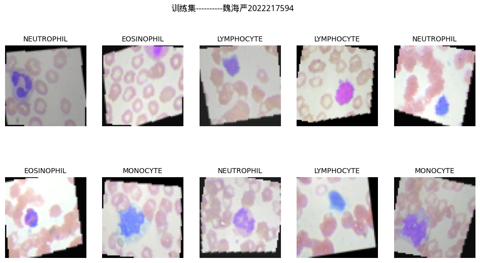

[figure not shown]

```python
import random
def show_sample_images(dataset, label_names, dataset_type, num_images=10):
    # 从数据集中随机采样
    sampled_indices = random.sample(range(len(dataset)), num_images)

    rows = (num_images + 4) // 5  # 计算行数，确保每行5张图片
    plt.figure(figsize=(12, 3 * rows))

    for i, idx in enumerate(sampled_indices):
        image, label = dataset[idx]

        # 逆标准化
        image = image.permute(1, 2, 0).numpy()
        mean = np.array([0.485, 0.456, 0.406])
        std = np.array([0.229, 0.224, 0.225])
        image = std * image + mean
        image = np.clip(image, 0, 1)  # 限制数据范围在 [0, 1] 之间

        plt.subplot(rows, 5, i + 1)
        plt.imshow(image)
        plt.title(label_names[label], fontsize=10)
        plt.xticks(fontsize=8)  # 设置横坐标字体大小
        plt.yticks(fontsize=8)  # 设置纵坐标字体大小
        plt.axis('off')

    plt.suptitle(dataset_type, font=Path('/usr/share/fonts/truetype/wqy/wqy-microhei.ttc'), size="large")
    plt.subplots_adjust(hspace=0.3)  # 调整子图之间的间距
    plt.show()
show_sample_images(train_dataset, label_names, "训练集----------魏海严2022217594")
show_sample_images(test_dataset, label_names, "测试集----------魏海严2022217594")
```

## 详细说明

### 数据加载器的作用

数据加载器（DataLoader）是PyTorch中用于加载数据的核心工具之一。它能够将数据集按指定的批量大小进行分割，并在训练过程中按批次提供数据。使用数据加载器的好处包括：

1. **批量处理数据**：
   - 数据加载器可以按批次加载数据，每次迭代训练时只处理一个批次的数据，从而提高内存利用率和计算效率。
2. **数据打乱（Shuffle）**：
   - 在训练数据加载器中设置`shuffle=True`，可以在每个epoch开始时随机打乱数据。这样可以防止模型对数据顺序产生依赖，提高模型的泛化能力。
   - 在测试数据加载器中设置`shuffle=False`，可以保持数据的顺序一致性，有助于评估模型的性能。
3. **异步数据加载**：
   - 数据加载器可以在后台进程中异步加载数据，避免数据加载成为训练的瓶颈，从而加快训练速度。

### 批量大小的选择

批量大小（batch_size）的选择对模型训练有重要影响：

```python
# Create dataloaders to load the data in batches
batch_size = 32 #In general, a larger batch size can lead to faster convergence and a better model performance, but it can also require more memory and computation. A smaller batch size can require more epochs to converge and may lead to a lower model performance, but it can be more memory-efficient and may be easier to fit on a single GPU.
train_dataloader = torch.utils.data.DataLoader(train_dataset, batch_size=batch_size, shuffle=True)
test_dataloader = torch.utils.data.DataLoader(test_dataset, batch_size=batch_size, shuffle=False)
```

### 调整布局并显示图表：

```python
# 从数据加载器中提取数据并转换为DataFrame
def extract_data(dataloader, num_batches=1):
    images, labels = [], []
    for i, (data, target) in enumerate(dataloader):
        if i >= num_batches:
            break
        images.append(data)
        labels.append(target)
    images = torch.cat(images)
    labels = torch.cat(labels)
    # 将图像展平并转换为NumPy数组
    flattened_images = images.view(images.size(0), -1).numpy()
    labels = labels.numpy()
    return flattened_images, labels

train_images, train_labels = extract_data(train_dataloader)
test_images, test_labels = extract_data(test_dataloader)

# 创建DataFrame
train_df = pd.DataFrame(train_images)
train_df['label'] = train_labels
test_df = pd.DataFrame(test_images)
test_df['label'] = test_labels

# 绘制散点图矩阵和密度图
def plotScatterMatrix(df, plotSize, textSize):
    df = df.select_dtypes(include=[np.number])  # 保留数值列
    df = df.dropna(axis='columns')  # 删除含有空值的列
    df = df[[col for col in df if df[col].nunique() > 1]]  # 保留有超过一个唯一值的列
    columnNames = list(df)
    if len(columnNames) > 10:  # 限制列数
        columnNames = columnNames[:10]
    df = df[columnNames]
    ax = pd.plotting.scatter_matrix(df, alpha=0.75, figsize=[plotSize, plotSize], diagonal='kde')
    corrs = df.corr().values
    for i, j in zip(*np.triu_indices_from(corrs, k=1)):
        ax[i, j].annotate('Corr. coef = %.3f' % corrs[i, j], (0.8, 0.2), xycoords='axes fraction', ha='center', va='center', size=textSize)
    plt.suptitle('Scatter and Density Plot', fontsize=textSize)
    plt.show()

# 示例使用
plotScatterMatrix(train_df, plotSize=10, textSize=12)
```

[output not shown]

## 详细说明

### 设备的定义

在深度学习中，设备（device）的选择对计算效率有很大的影响。PyTorch提供了对GPU（通常是CUDA设备）的支持，可以显著加速模型的训练和推理过程。以下是定义设备的详细解释：

1. **检查CUDA是否可用**：
   - `torch.cuda.is_available()`：这是一个布尔值函数，用于检查系统中是否有可用的CUDA设备（GPU）。如果有可用的CUDA设备，该函数返回True，否则返回False。
2. **定义设备**：
   - `torch.device('cuda')`：如果系统中有可用的CUDA设备，将设备定义为CUDA设备，这样所有的张量和模型都会在GPU上运行，从而利用GPU的并行计算能力，加速训练和推理过程。
   - `torch.device('cpu')`：如果系统中没有可用的CUDA设备，将设备定义为CPU，这样所有的张量和模型都会在CPU上运行。虽然速度较慢，但这种方式确保了代码的通用性，可以在没有GPU的系统上运行。
3. **设备定义的代码解释**：

   ```
   device = torch.device('cuda' if torch.cuda.is_available() else 'cpu')
   ```

```python
# Define the device
device = torch.device('cuda' if torch.cuda.is_available() else 'cpu')
```

## 详细说明

### ResidualBlock 类

#### **init** 方法：

conv1：第一个卷积层，输入通道数为 in_channels，输出通道数为 out_channels，卷积核大小为 3x3，步幅为 stride，填充为1。 bn1：第一个批量归一化层，作用于第一个卷积层的输出。 conv2：第二个卷积层，输入通道数为 out_channels，输出通道数为 out_channels，卷积核大小为 3x3，步幅为1，填充为1。 bn2：第二个批量归一化层，作用于第二个卷积层的输出。 shortcut：捷径连接，如果输入和输出的通道数不同，或者步幅不为1，则进行卷积操作，否则直接跳过连接。

#### forward 方法：

将输入 x 通过第一个卷积层、批量归一化层和 ReLU 激活函数。 将输出通过第二个卷积层和批量归一化层。 将结果与捷径连接的输出相加。 通过 ReLU 激活函数返回结果。

### ImprovedCNN 类

#### **init** 方法：

conv1：第一个卷积层，输入通道数为3（RGB图像），输出通道数为16，卷积核大小为3x3，填充为1。 bn1：第一个批量归一化层，作用于第一个卷积层的输出。 res1：第一个残差块，输入通道数为16，输出通道数为32。 pool1：第一个最大池化层，池化窗口大小为2x2，步幅为2。 res2：第二个残差块，输入通道数为32，输出通道数为64。 pool2：第二个最大池化层，池化窗口大小为2x2，步幅为2。 res3：第三个残差块，输入通道数为64，输出通道数为128。 pool3：第三个最大池化层，池化窗口大小为2x2，步幅为2。 dropout：Dropout 层，随机失活神经元，防止过拟合。 fc1：第一个全连接层，输入大小根据池化后的输出调整。 fc2：第二个全连接层，输出大小为256。 fc3：输出层，输出大小为4，对应4个类别。

#### forward 方法：

将输入 x 通过第一个卷积层和批量归一化层，然后通过 ReLU 激活函数。 通过第一个残差块和第一个池化层。 通过第二个残差块和第二个池化层。 通过第三个残差块和第三个池化层。 展平张量，为全连接层做准备。 通过 Dropout 层和第一个全连接层。 通过第二个全连接层。 通过输出层，返回最终结果。

```python
class ResidualBlock(nn.Module):
    def __init__(self, in_channels, out_channels, stride=1):
        super(ResidualBlock, self).__init__()
        self.conv1 = nn.Conv2d(in_channels, out_channels, kernel_size=3, stride=stride, padding=1)
        self.bn1 = nn.BatchNorm2d(out_channels)
        self.conv2 = nn.Conv2d(out_channels, out_channels, kernel_size=3, stride=1, padding=1)
        self.bn2 = nn.BatchNorm2d(out_channels)

        self.shortcut = nn.Sequential()
        if stride != 1 or in_channels != out_channels:
            self.shortcut = nn.Sequential(
                nn.Conv2d(in_channels, out_channels, kernel_size=1, stride=stride),
                nn.BatchNorm2d(out_channels)
            )

    def forward(self, x):
        out = F.relu(self.bn1(self.conv1(x)))
        out = self.bn2(self.conv2(out))
        out += self.shortcut(x)
        out = F.relu(out)
        return out

class ImprovedCNN(nn.Module):
    def __init__(self):
        super(ImprovedCNN, self).__init__()
        self.conv1 = nn.Conv2d(3, 16, 3, padding=1)
        self.bn1 = nn.BatchNorm2d(16)
        self.res1 = ResidualBlock(16, 32)
        self.pool1 = nn.MaxPool2d(2, 2)
        self.res2 = ResidualBlock(32, 64)
        self.pool2 = nn.MaxPool2d(2, 2)
        self.res3 = ResidualBlock(64, 128)
        self.pool3 = nn.MaxPool2d(2, 2)
        self.dropout = nn.Dropout(0.5)
        self.fc1 = nn.Linear(128 * 8 * 8, 512)  # 根据输出大小调整
        self.fc2 = nn.Linear(512, 256)
        self.fc3 = nn.Linear(256, 4)

    def forward(self, x):
        x = F.relu(self.bn1(self.conv1(x)))

        x = self.res1(x)

        x = self.pool1(x)

        x = self.res2(x)

        x = self.pool2(x)

        x = self.res3(x)

        x = self.pool3(x)

        x = x.view(-1, 128 * 8 * 8)  # 根据输出大小调整

        x = self.dropout(F.relu(self.fc1(x)))
        x = F.relu(self.fc2(x))
        x = self.fc3(x)
        return x
```

## 模型初始化、损失函数、优化器和学习率调度器的详细解释：

### 1. 模型初始化:

```
- 这行代码初始化了 `ImprovedCNN` 模型，并将其移到指定的设备上（如 GPU 或 CPU）。使用 `model.to(device)` 可以确保模型的所有参数都在正确的设备上。
- `ImprovedCNN` 是一个自定义的卷积神经网络模型，包含多个卷积层、残差块和全连接层。
```

### 2. 定义损失函数:

```
- `loss_fn = nn.CrossEntropyLoss()` 定义了交叉熵损失函数，这是分类问题中常用的损失函数。
- 交叉熵损失函数在计算预测结果与实际标签之间的差异时，适用于多类分类任务。
- 它期望模型的输出为未归一化的类分数（即 logits），并自动应用 softmax 以计算概率分布。
```

### 3. 定义优化器:

```
- `optimizer = optim.Adam(model.parameters(), lr=0.001)` 初始化了 Adam 优化器，并设置了学习率为 0.001。
- Adam（Adaptive Moment Estimation）优化器结合了动量梯度下降和 RMSProp 的优点，在实践中表现非常好。
- `model.parameters()` 返回模型的所有可训练参数，优化器将根据这些参数和梯度更新模型权重。
```

### 4. 定义学习率调度器:

```
- `scheduler = optim.lr_scheduler.StepLR(optimizer, step_size=7, gamma=0.1)` 定义了一个学习率调度器，用于动态调整学习率。
- `StepLR` 调度器每经过 `step_size` 个周期（这里是7个周期），将学习率乘以 `gamma`（这里是0.1）。
- 动态调整学习率可以帮助模型在训练过程中更好地收敛，避免陷入局部最优解。
```

### 总结:

### 这几行代码共同作用，初始化了模型、定义了损失函数和优化器，并设置了学习率调度器。通过这些步骤，我们为模型的训练过程做好了准备：

#### - 模型将使用 Adam 优化器进行权重更新。

#### - 交叉熵损失函数将衡量模型的预测与真实标签之间的差异。

#### - 学习率调度器将根据预定义的规则动态调整学习率，以促进更有效的训练。

```python
# Initialize the model
model = ImprovedCNN().to(device)
loss_fn = nn.CrossEntropyLoss()
# Define the loss function and the optimizer
optimizer = optim.Adam(model.parameters(), lr=0.001)
scheduler = optim.lr_scheduler.StepLR(optimizer, step_size=7, gamma=0.1)
```

## 详细说明

#### 定义训练的轮数：

- `num_epochs = 30`：定义训练的总轮数，即模型将遍历整个训练数据集的次数。在这个例子中，模型将训练30个轮次。

#### 初始化一个空列表用于存储损失值：

- `losses = []`：初始化一个空列表losses，用于存储每个epoch的损失值。通过记录每个epoch的损失值，可以在训练结束后绘制损失曲线，以观察模型的收敛情况。

#### 训练模型：

- `for epoch in range(num_epochs)`：开始训练循环，对每个epoch进行训练。
- `model.train()`：将模型设置为训练模式，启用dropout层和批量归一化层的训练行为。

#### 批次循环：

- `for inputs, labels in train_dataloader`：开始一个epoch内的批次循环，对每个批次的数据进行训练。
- `inputs = inputs.to(device)`：将输入数据移动到指定设备（如GPU）。
- `labels = labels.to(device)`：将标签移动到指定设备（如GPU）。

#### 前向传播：

- `logits = model(inputs)`：使用模型对输入数据进行前向传播，计算输出logits。logits是模型的未归一化输出（即未经过softmax的类分数）。

#### 计算损失：

- `loss = loss_fn(logits, labels)`：使用定义的损失函数计算模型输出与实际标签之间的损失。在这里，使用交叉熵损失函数来衡量模型的预测与真实标签之间的差异。

#### 反向传播和参数更新：

- `optimizer.zero_grad()`：在进行反向传播之前，先将优化器的梯度缓存清零。每次调用backward()计算梯度时，梯度都会累加在现有的梯度上，因此在每次迭代中都需要清零梯度。
- `loss.backward()`：进行反向传播，计算模型参数的梯度。调用loss.backward()会计算损失相对于模型参数的梯度，并存储在模型参数的.grad属性中。
- `optimizer.step()`：使用优化器更新模型参数。调用optimizer.step()会根据当前的梯度和优化算法更新模型的参数，以最小化损失。

#### 记录和打印损失：

- `losses.append(loss.item())`：将当前epoch的损失值添加到losses列表中。这里使用loss.item()获取损失值的标量表示，并存储在列表中。
- `print(f'Loss at epoch {epoch+1}: {loss.item():.4f}')`：打印当前epoch的损失值，以监控训练过程中的损失变化。

```python
# Define the number of epochs
num_epochs = 30
# Initialize an empty list to store the losses
losses = []

# Train the model
for epoch in range(num_epochs):
    model.train()
    for inputs, labels in train_dataloader:
        inputs = inputs.to(device)
        labels = labels.to(device)
        logits = model(inputs)
        loss = loss_fn(logits, labels)

        optimizer.zero_grad()
        loss.backward()
        optimizer.step()

    # Append the loss to the list
    losses.append(loss.item())

    # Print the loss
    print(f'Loss at epoch {epoch+1}: {loss.item():.4f}')
```

```
Loss at epoch 1: 1.4149
Loss at epoch 2: 1.0572
Loss at epoch 3: 1.2282
Loss at epoch 4: 0.8010
Loss at epoch 5: 0.2873
Loss at epoch 6: 0.2770
Loss at epoch 7: 0.2066
Loss at epoch 8: 0.1950
Loss at epoch 9: 0.1540
Loss at epoch 10: 0.2123
Loss at epoch 11: 0.1688
Loss at epoch 12: 0.1042
Loss at epoch 13: 0.1103
Loss at epoch 14: 0.3710
Loss at epoch 15: 0.0448
Loss at epoch 16: 0.2749
Loss at epoch 17: 0.0485
Loss at epoch 18: 0.1548
Loss at epoch 19: 0.0929
Loss at epoch 20: 0.0397
Loss at epoch 21: 0.2454
Loss at epoch 22: 0.1831
Loss at epoch 23: 0.0749
Loss at epoch 24: 0.0138
Loss at epoch 25: 0.0967
Loss at epoch 26: 0.3102
Loss at epoch 27: 0.0118
Loss at epoch 28: 0.1256
Loss at epoch 29: 0.1964
Loss at epoch 30: 0.0010
```

**最后，调用`plt.show()`来显示绘制的图表。调用此函数后，图表窗口会弹出，展示损失值变化曲线。这段代码的主要功能是配置Matplotlib以支持中文标签，然后绘制并展示模型训练过程中损失值变化的曲线图。通过这些步骤，我们能够直观地观察模型在每个训练轮次的损失值，从而评估模型的收敛情况和性能。**

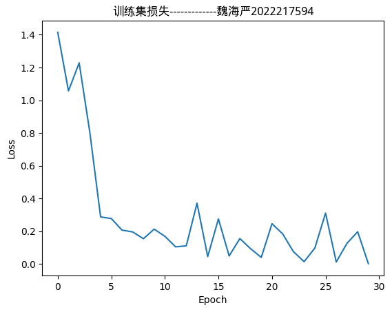

```python
import matplotlib.pyplot as plt
from pathlib import Path

import matplotlib.pyplot as plt

# Plot the loss values
plt.plot(losses)
plt.xlabel('Epoch')
plt.ylabel('Loss')
plt.title('训练集损失-------------魏海严2022217594', font=Path('/usr/share/fonts/truetype/wqy/wqy-microhei.ttc'), size="large")
plt.show()
#plt.rcParams['font.family']='AR PL UKai CN'


#plt.title("generated layout损", font=Path('/usr/share/fonts/truetype/wqy/wqy-microhei.ttc'), size="large")
```

## 实现了一个神经网络模型的训练和验证过程。它分为三个主要部分：训练函数、验证函数以及训练和验证循环。

### **训练函数 (`train`)**:

1. - 目的：通过多次迭代更新模型的参数，以最小化损失函数。
   - 操作：
     - 将模型设置为训练模式 (`model.train()`)，启用如 Dropout 等训练时特有的操作。
     - 初始化训练损失为 0。
     - 遍历训练数据加载器 (`train_dataloader`) 获取每个批次的数据。
     - 将每个批次的数据和标签转移到指定的设备（CPU或GPU），并清除优化器中的梯度信息。
     - 将输入数据传入模型，得到输出（logits），并通过损失函数计算损失。
     - 进行反向传播以计算梯度，并更新模型参数。
     - 每次计算的损失会累加到训练损失中。
   - 返回平均训练损失。

### **验证函数 (`validate`)**:

2. - 目的：评估模型在验证数据集上的表现。
   - 操作：
     - 将模型设置为评估模式 (`model.eval()`)，禁用如 Dropout 等训练时特有的操作，并通过 `torch.no_grad()` 来禁用梯度计算，节省内存并提高验证速度。
     - 初始化验证损失为 0。
     - 遍历验证数据加载器 (`test_dataloader`) 获取每个批次的数据。
     - 将每个批次的数据和标签转移到指定的设备（CPU或GPU）。
     - 将输入数据传入模型，得到输出。
     - 通过损失函数计算损失，并将每次的损失累加到验证损失中。
   - 返回平均验证损失。

### **训练和验证循环**:

3. - 负责协调多个训练轮次和验证。
   - 设置训练的总轮数为 30 (`num_epochs = 30`)，并初始化存储每轮训练和验证损失的列表。
   - 在每个训练轮次中：
     - 调用 `train` 函数进行一次完整的训练，并返回该轮次的平均训练损失。
     - 调用 `validate` 函数进行一次完整的验证，并返回该轮次的平均验证损失。
     - 将这些损失值添加到相应的列表中，并打印当前轮次的训练和验证损失。

通过这个过程，模型的训练和验证损失会在每个轮次中被记录和输出，帮助监控训练过程的进展和模型的性能表现。

```python
def train(model, train_dataloader, optimizer, loss_fn):
    model.train()
    train_loss = 0
    for inputs, labels in train_dataloader:
        inputs, labels = inputs.to(device), labels.to(device)
        optimizer.zero_grad()
        logits = model(inputs)
        loss = loss_fn(logits, labels)
        loss.backward()
        optimizer.step()
        train_loss += loss.item()
    return train_loss / len(train_dataloader)

def validate(model, test_dataloader, loss_fn):
    model.eval()
    valid_loss = 0
    with torch.no_grad():
        for inputs, labels in test_dataloader:
            inputs, labels = inputs.to(device), labels.to(device)
            logits = model(inputs)
            loss = loss_fn(logits, labels)
            valid_loss += loss.item()
    return valid_loss / len(test_dataloader)

# 训练模型并记录损失
num_epochs = 30
train_losses = []
valid_losses = []

for epoch in range(num_epochs):
    train_loss = train(model, train_dataloader, optimizer, loss_fn)
    valid_loss = validate(model, test_dataloader, loss_fn)
    train_losses.append(train_loss)
    valid_losses.append(valid_loss)
    print(f'Epoch {epoch+1}/{num_epochs}, Train Loss: {train_loss:.4f}, Validation Loss: {valid_loss:.4f}')
```

[output not shown]

### 配置Matplotlib以支持中文显示，绘制并展示训练和验证的损失曲线，从而直观地展示模型在每个训练轮次的表现。通过观察这些曲线，可以更好地了解模型的训练动态，评估模型的表现。

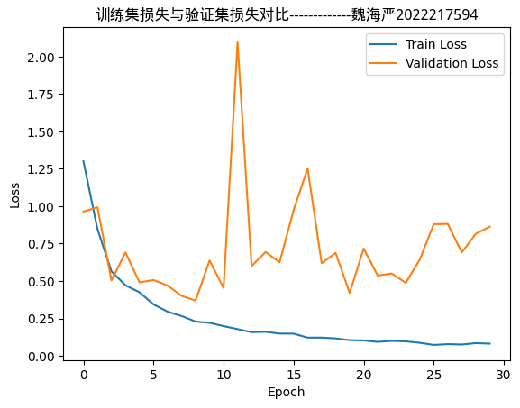

```python
# 显示训练和验证的损失曲线
plt.rcParams['font.family'] = ['sans-serif']
plt.rcParams['font.sans-serif'] = ['SimHei']
plt.rcParams['axes.unicode_minus'] = False
plt.plot(train_losses, label='Train Loss')
plt.plot(valid_losses, label='Validation Loss')
plt.xlabel('Epoch')
plt.ylabel('Loss')
plt.title('训练集损失与验证集损失对比-------------魏海严2022217594', font=Path('/usr/share/fonts/truetype/wqy/wqy-microhei.ttc'), size="large")
plt.legend()
plt.show()
```

# 模型评估函数详解

评估单独ImprovedCNN模型在测试数据上的性能。此代码主要适用于需要评估分类模型准确性、F1分数和AUC分数的场景。

## 功能概述

- **输入**：一个经过训练的ImprovedCNN模型和测试数据集的加载器。
- **输出**：模型在测试数据上的准确率、F1分数和AUC分数。

## 实现步骤

### 1. 模型设置为评估模式

- 使用`model.eval()`将模型设置为评估模式，这是评估阶段禁用Dropout和Batch normalization的标准做法。

### 2. 初始化存储列表

- `true_labels = []`：存储真实标签。
- `pred_probs = []`：存储预测概率。

### 3. 数据迭代和概率计算

- 在`torch.no_grad()`环境下执行，避免进行不必要的计算。
- 遍历数据加载器中的所有数据，对每个批次的输入数据进行预测，计算Softmax概率。

### 4. 性能评估

- 将收集到的标签和概率列表转换为NumPy数组。
- 使用`sklearn.metrics`计算准确率、F1分数和AUC分数。

```python
from sklearn.metrics import accuracy_score, f1_score, roc_auc_score
import numpy as np

# Set model to evaluation mode
model.eval()

# Initialize lists to store true labels and predicted labels
true_labels = []
pred_probs = []  # store predicted probabilities instead of labels

# Iterate through the test data
with torch.no_grad():
    for inputs, labels in test_dataloader:
        inputs = inputs.to(device)
        labels = labels.to(device)
        logits = model(inputs)
        probs = torch.softmax(logits, dim=1)  # calculate probabilities

        # Add true labels and predicted probabilities to lists
        true_labels.extend(labels.tolist())
        pred_probs.extend(probs.tolist())

# Convert lists to numpy arrays
true_labels = np.array(true_labels)
pred_probs = np.array(pred_probs)

# Calculate accuracy, F1 score, and AUC score
acc = accuracy_score(true_labels, np.argmax(pred_probs, axis=1))
f1 = f1_score(true_labels, np.argmax(pred_probs, axis=1), average='macro')
auc = roc_auc_score(true_labels, pred_probs, multi_class='ovo')

# Print results
print(f'Test accuracy: {acc:.4f}')
print(f'Test F1 score: {f1:.4f}')
print(f'Test AUC score: {auc:.4f}')
```

```
Test accuracy: 0.9369
Test F1 score: 0.9369
Test AUC score: 0.9948
```

## 详细说明

### 训练模型的步骤

上述代码定义了一个用于训练模型的函数 `train_model`。该函数通过迭代训练数据加载器的每个批次来更新模型的权重。以下是对每个步骤的详细解释：

#### 将模型设置为训练模式：

`model.train()` 将模型切换到训练模式。这会启用一些特定于训练的层（如 Dropout 和 BatchNorm）来进行参数更新。

#### 迭代训练数据的每个 epoch：

`for epoch in range(num_epochs)` 开始训练循环，每个 epoch 代表一次完整的训练数据集遍历。

#### 迭代每个批次的数据：

`for inputs, labels in train_dataloader` 在每个 epoch 中，遍历训练数据加载器中的每个批次。`train_dataloader` 按批次提供数据。

#### 将数据移动到指定设备：

`inputs = inputs.to(device)` 和 `labels = labels.to(device)` 将输入数据和标签移动到指定的设备（如 GPU），以加速计算。

#### 前向传播计算输出：

`logits = model(inputs)` 通过模型进行前向传播，计算输出 `logits`。

#### 计算损失：

`loss = loss_fn(logits, labels)` 使用定义的损失函数 `loss_fn` 计算模型输出与真实标签之间的损失。这里使用的是交叉熵损失函数。

#### 梯度清零：

`optimizer.zero_grad()` 清除优化器中所有参数的梯度缓存。每次迭代时，梯度会累积，因此需要在每次反向传播之前清零。

#### 反向传播计算梯度：

`loss.backward()` 执行反向传播，计算损失相对于模型参数的梯度，并存储在每个参数的 `.grad` 属性中。

#### 更新模型参数：

`optimizer.step()` 使用优化器更新模型的参数。优化器根据计算出的梯度和学习率等超参数，调整模型参数以最小化损失。

#### 打印当前 epoch 的损失值：

通过这些步骤，模型的参数在每个批次中逐步更新，使得模型能够学习到更好的特征表示，从而提高在验证集或测试集上的性能。训练过程中的损失值变化能够帮助我们判断模型是否在有效地学习，以及是否存在过拟合或欠拟合的情况。

```python
def train_model(model, train_dataloader, optimizer, loss_fn, num_epochs):
    model.train()
    for epoch in range(num_epochs):
        for inputs, labels in train_dataloader:
            inputs = inputs.to(device)
            labels = labels.to(device)
            logits = model(inputs)
            loss = loss_fn(logits, labels)

            optimizer.zero_grad()
            loss.backward()
            optimizer.step()

        print(f'Epoch [{epoch+1}/{num_epochs}], Loss: {loss.item():.4f}')
```

# 集成学习训练概览

初始化和训练多个卷积神经网络模型的过程。脚本通过循环结构来处理集成学习训练，便于扩展和比较不同训练运行的结果。

## 逐步解释

### 初始化

- `num_models = 5`：定义要训练的模型数量。
- `models = []`：初始化一个空列表，用于存储训练后的模型。

### 训练循环

每次迭代循环将执行以下步骤：

```python
# 集成学习
num_models = 5
models = []
for _ in range(num_models):
    model = ImprovedCNN().to(device)
    optimizer = optim.Adam(model.parameters(), lr=0.001)
    loss_fn = nn.CrossEntropyLoss()
    train_model(model, train_dataloader, optimizer, loss_fn, num_epochs=30)
    models.append(model)
```

```
Epoch [1/30], Loss: 1.3749
Epoch [2/30], Loss: 1.0015
Epoch [3/30], Loss: 0.7307
Epoch [4/30], Loss: 0.3716
Epoch [5/30], Loss: 0.3470
Epoch [6/30], Loss: 0.5918
Epoch [7/30], Loss: 0.2624
Epoch [8/30], Loss: 0.3016
Epoch [9/30], Loss: 0.1557
Epoch [10/30], Loss: 0.2492
Epoch [11/30], Loss: 0.2261
Epoch [12/30], Loss: 0.1431
Epoch [13/30], Loss: 0.1274
Epoch [14/30], Loss: 0.0164
Epoch [15/30], Loss: 0.1738
Epoch [16/30], Loss: 0.3377
Epoch [17/30], Loss: 0.1322
Epoch [18/30], Loss: 0.1146
Epoch [19/30], Loss: 0.0437
Epoch [20/30], Loss: 0.0527
Epoch [21/30], Loss: 0.0589
Epoch [22/30], Loss: 0.0056
Epoch [23/30], Loss: 0.1014
Epoch [24/30], Loss: 0.2772
Epoch [25/30], Loss: 0.2939
Epoch [26/30], Loss: 0.1549
Epoch [27/30], Loss: 0.0425
Epoch [28/30], Loss: 0.0296
Epoch [29/30], Loss: 0.0790
Epoch [30/30], Loss: 0.0225
Epoch [1/30], Loss: 1.0744
Epoch [2/30], Loss: 0.9460
Epoch [3/30], Loss: 0.4819
Epoch [4/30], Loss: 0.5088
Epoch [5/30], Loss: 0.4265
Epoch [6/30], Loss: 0.4482
Epoch [7/30], Loss: 0.1506
Epoch [8/30], Loss: 0.1724
Epoch [9/30], Loss: 0.4271
Epoch [10/30], Loss: 0.0376
```

[output cut: 95 more lines]

```
Epoch [16/30], Loss: 0.0543
Epoch [17/30], Loss: 0.0855
Epoch [18/30], Loss: 0.4100
Epoch [19/30], Loss: 0.0677
Epoch [20/30], Loss: 0.1075
Epoch [21/30], Loss: 0.0386
Epoch [22/30], Loss: 0.0553
Epoch [23/30], Loss: 0.2325
Epoch [24/30], Loss: 0.0734
Epoch [25/30], Loss: 0.1560
Epoch [26/30], Loss: 0.0164
Epoch [27/30], Loss: 0.2041
Epoch [28/30], Loss: 0.0087
Epoch [29/30], Loss: 0.0302
Epoch [30/30], Loss: 0.0374
```

# 集成模型评估函数概述

本文档提供了一个评估函数`evaluate_ensemble`的详细解析，该函数用于评估通过多个模型集成进行分类任务的性能。此函数主要用于机器学习中的模型集成技术，目的是通过组合多个模型的预测来提高整体的预测准确性。

## 函数功能

- **输入**：模型列表和测试数据加载器。
- **输出**：模型集成的准确率、F1分数和AUC分数。

## 函数实现步骤

1. **初始化标签和预测概率列表**：
   - `true_labels = []`：存储真实标签。
   - `pred_probs = []`：存储预测概率。
2. **模型预测和集成**：
   - 在`torch.no_grad()`环境中进行，以防止计算梯度，优化性能。
   - 遍历测试数据集中的每个样本批次。
   - 为每个模型生成的logits求和，然后平均，使用Softmax函数转换为概率。
3. **性能评估**：
   - 使用`numpy`和`sklearn.metrics`库计算准确率、F1分数和AUC分数。
   - 打印输出这些评估指标。

```python
import torch
import numpy as np
from sklearn.metrics import accuracy_score, f1_score, roc_auc_score
from PIL import Image
import matplotlib.pyplot as plt

def evaluate_ensemble(models, test_dataloader, device):
    true_labels = []
    pred_probs = []

    with torch.no_grad():
        for inputs, labels in test_dataloader:
            inputs = inputs.to(device)
            labels = labels.to(device)
            ensemble_logits = torch.zeros((inputs.size(0), 4)).to(device)
            for model in models:
                model.eval()  # Ensure model is in evaluation mode
                logits = model(inputs)
                ensemble_logits += logits
            ensemble_probs = torch.softmax(ensemble_logits / len(models), dim=1)

            true_labels.extend(labels.tolist())
            pred_probs.extend(ensemble_probs.tolist())

    true_labels = np.array(true_labels)
    pred_probs = np.array(pred_probs)

    acc = accuracy_score(true_labels, np.argmax(pred_probs, axis=1))
    f1 = f1_score(true_labels, np.argmax(pred_probs, axis=1), average='macro')
    auc = roc_auc_score(true_labels, pred_probs, multi_class='ovo')

    print(f'Test accuracy: {acc:.4f}')
    print(f'Test F1 score: {f1:.4f}')
    print(f'Test AUC score: {auc:.4f}')
evaluate_ensemble(models, test_dataloader, device)
```

```
Test accuracy: 0.9453
Test F1 score: 0.9453
Test AUC score: 0.9966
```

```python
import torch
import numpy as np
from sklearn.metrics import accuracy_score, f1_score, roc_auc_score
from collections import Counter

def evaluate_ensemble_voting(models, test_dataloader, device):
    true_labels = []
    pred_labels = []

    with torch.no_grad():
        for inputs, labels in test_dataloader:
            inputs = inputs.to(device)
            labels = labels.to(device)
            batch_pred_labels = []

            for model in models:
                model.eval()  # Ensure model is in evaluation mode
                logits = model(inputs)
                probs = torch.softmax(logits, dim=1)
                batch_pred_labels.append(torch.argmax(probs, dim=1).cpu().numpy())

            # Transpose to get predictions of each sample across all models
            batch_pred_labels = np.array(batch_pred_labels).T

            # Voting: Choose the most common prediction for each sample
            voted_labels = [Counter(pred).most_common(1)[0][0] for pred in batch_pred_labels]

            true_labels.extend(labels.cpu().tolist())
            pred_labels.extend(voted_labels)

    true_labels = np.array(true_labels)
    pred_labels = np.array(pred_labels)

    acc = accuracy_score(true_labels, pred_labels)
    f1 = f1_score(true_labels, pred_labels, average='macro')
    auc = roc_auc_score(true_labels, np.eye(4)[pred_labels], multi_class='ovo')

    print(f'Test accuracy: {acc:.4f}')
    print(f'Test F1 score: {f1:.4f}')
    print(f'Test AUC score: {auc:.4f}')

# 假设 models 是之前训练好的多个模型的列表
# 假设 device 已经被定义
evaluate_ensemble_voting(models, test_dataloader, device)
```

[output not shown]

# 集成模型评估及混淆矩阵绘制

本文档详细介绍了如何使用Python代码评估集成模型的性能并绘制混淆矩阵，以可视化模型在各类别上的预测准确性。

## 功能概述

- **输入**：多个模型构成的集成模型和测试数据集的加载器。
- **输出**：混淆矩阵的可视化，展示模型预测类别与真实类别的对比。

## 实现步骤

### 1. 集成模型评估

- 使用多个单独的模型对测试数据进行预测，并通过某种策略（如投票或平均）合并这些预测结果。

### 2. 混淆矩阵绘制

- 计算并绘制混淆矩阵，以图形方式展示每个类别的预测结果和实际结果。

[figure not shown]

```python
from sklearn.metrics import accuracy_score, f1_score, roc_auc_score, confusion_matrix
def evaluate_ensemble(models, test_dataloader):
    true_labels = []
    pred_probs = []
    pred_labels = []

    with torch.no_grad():
        for inputs, labels in test_dataloader:
            inputs = inputs.to(device)
            labels = labels.to(device)
            ensemble_logits = torch.zeros((inputs.size(0), 4)).to(device)
            for model in models:
                logits = model(inputs)
                ensemble_logits += logits
            ensemble_probs = torch.softmax(ensemble_logits / len(models), dim=1)
            ensemble_preds = torch.argmax(ensemble_probs, dim=1)

            true_labels.extend(labels.tolist())
            pred_probs.extend(ensemble_probs.tolist())
            pred_labels.extend(ensemble_preds.tolist())

    true_labels = np.array(true_labels)
    pred_probs = np.array(pred_probs)
    pred_labels = np.array(pred_labels)

    acc = accuracy_score(true_labels, pred_labels)
    f1 = f1_score(true_labels, pred_labels, average='macro')
    auc = roc_auc_score(true_labels, pred_probs, multi_class='ovo')

   # print(f'Test accuracy: {acc:.4f}')
   # print(f'Test F1 score: {f1:.4f}')
   # print(f'Test AUC score: {auc:.4f}')

    # 绘制混淆矩阵
    confusion = confusion_matrix(true_labels, pred_labels)
    plt.figure(figsize=(7, 7))
    sns.heatmap(confusion, annot=True, cbar=False,
                xticklabels=label_names,
                yticklabels=label_names)
    plt.title('混淆矩阵-------------魏海严2022217594', font=Path('/usr/share/fonts/truetype/wqy/wqy-microhei.ttc'), size="large")
    plt.ylabel('Actual class')
    plt.xlabel('Predicted class')
    plt.show()

# 评估集成模型并绘制混淆矩阵
evaluate_ensemble(models, test_dataloader)
```

# 模型预测单图像分类

进行图像预处理和模型预测，包括如何加载图像、应用变换、预测类别以及展示预测结果。

## 功能概述

- **输入**：图像文件路径。
- **输出**：图像的预测类别名称。

## 实现步骤

### 1. 加载图像

首先，使用Pillow库加载图像文件。

### 2. 图像预处理

通过定义一系列变换操作，将图像调整到模型要求的大小并进行标准化。

### 3. 模型预测

将预处理后的图像转换为PyTorch张量，使用预训练模型进行预测，并输出预测概率最高的类别。

```python
from PIL import Image

# Load the image and preprocess it
image = Image.open('./dataset2-master/dataset2-master/images/TEST/MONOCYTE/_0_1123.jpeg')
preprocess = transforms.Compose([
    transforms.Resize((64,64)),
    transforms.ToTensor(),
    transforms.Normalize([0.485, 0.456, 0.406], [0.229, 0.224, 0.225])
])
image = preprocess(image)

# Convert the image to a PyTorch tensor and send it to the device
image = image.unsqueeze(0).to(device)

# Make the prediction
with torch.no_grad():
    logits = model(image)
    probs = torch.softmax(logits, dim=1)
    pred_label = torch.argmax(probs, dim=1)

# Print the prediction
print(f'Predicted label: {pred_label.item()}')

# Map the predicted label to the corresponding class name
predicted_class_name = label_names[pred_label.item()]

# Print the predicted class name
print(f'Predicted class name: {predicted_class_name}')
```

```
Predicted label: 2
Predicted class name: MONOCYTE
```